# Roy Mwavita - Monitoring and Evaluation Officer

## About Me

**Roy Lennic Mwavita**  
**📞** +254 794 395 145  
**✉️** lennicroy@gmail.com  
**🌐 LinkedIn:** linkedin.com/in/roy-mwavita-495b50220

Results-oriented Monitoring, Evaluation, and Learning (MEL) professional with 2+ years of experience leading multi-county, donor-funded programs (USAID & PEPFAR). Skilled in managing end-to-end M&E systems, designing robust MEAL frameworks, and delivering data-driven insights through interactive dashboards, reports, and learning products.

Expert in tools such as **R, ODK, KoboToolbox, and CPIMS**, with a strong track record in conducting **Data Quality Assessments (DQAs)** and promoting data-informed decision-making across technical teams. Proficient in developing digital platforms, tracking performance metrics, and fostering peer learning to improve program outcomes.

Driven by a commitment to **evidence-based practices**, I excel in stakeholder engagement, capacity building, and ensuring compliance with donor standards to strengthen impact, accountability, and learning across humanitarian and health-focused interventions.

## Highlights

#### As a MEAL Officer, I performed the following:

- **Designed an R Shiny-powered OVC Analyzer** that flagged duplicate/overage beneficiaries—reducing registration errors by 90%.
- **Developed an R Shiny-powered Preventive Services Tracker and dashboard**, improving session attendance validation by 85%.
- **Led data quality assessments (DQAs)** and validation exercises to ensure data accuracy, completeness, and compliance with donor standards.
- **Led post-training assessments** using the KPI Repository hosted on GitHub—enhanced staff comprehension of indicators by 90%.
- **Promoted adaptive learning** by analyzing trends, generating insights, and supporting course-correction strategies with technical teams and stakeholders.
- **Facilitated capacity-building sessions** for partner organizations and field staff on data management, accountability frameworks, and M&E best practices.

## Core Competencies & Skills

- **M&E Frameworks**: Design, implementation, monitoring & results reporting.
- **Digital Data Platforms:** KoboToolbox, SurveyCTO, ODK
- **Dashboards & Visualization:** R Shiny, Power BI, Tableau
- **Data Analysis:** R, Python, STATA, Excel
- **Donor Reporting:** CPIMS, DATIM, narrative/quarterly reports
- **Learning & Capacity Building Sessions**
- **Knowledge Management & Repository Maintenance**
- **Collaborative Engagement with MOH, DCS, IPs**

[interactive chart not shown]

## Professional Experience

[interactive chart not shown]

## Education Background

| Degree/Certification | Institution | Location | Dates |
| --- | --- | --- | --- |
| Certification in Monitoring & Evaluation | Kenya Institute of Management | Virtual | July 2024 – November 2024 |
| Bachelor of Arts in Sociology | Pwani University | Kilifi, Kenya | September 2016 – June 2021 |

## Certifications

| Certification | Date |
| --- | --- |
| Humanitarian Needs Assessment – KoboToolbox | June 2024 |
| Data Analysis Essentials – Microsoft & LinkedIn | June 2024 |
| Project Management Essentials – Microsoft & LinkedIn | June 2024 |
| Data Demand and Information Use (DDIU) in the HIV Programme – NASCOP | April 2025 |

## Projects and Achievements

### 1. Preventive Analyzer Dashboard

- **Task**: Designed a dashboard to track evidence-based interventions for Sinovuyo and CBIM programs.
- **Action**: Automated raw data processing and created key performance metrics.
- **Result**: Enabled faster, data-driven decisions, improving program efficiency by 30%.

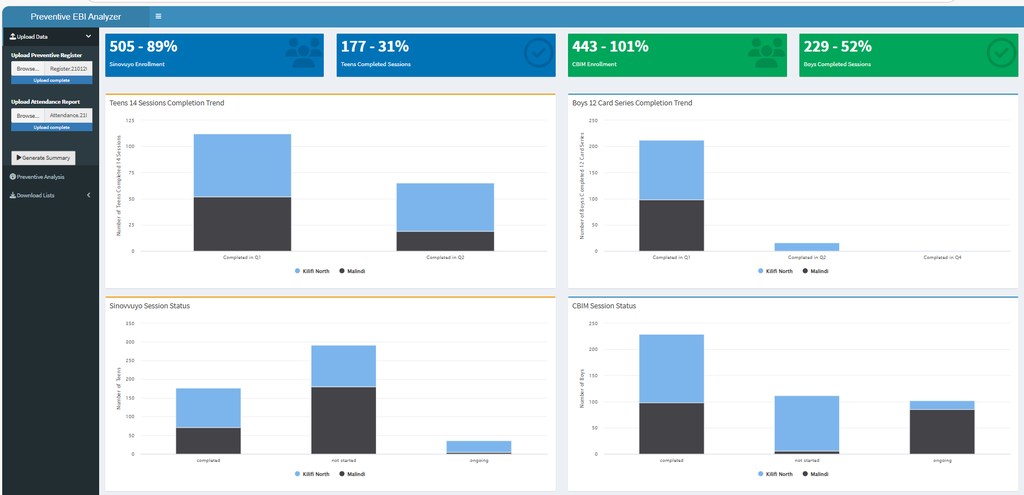

### 2. OVC Comprehensive Gaps Analyzer Dashboard

- **Task**: Identified gaps in OVC registration data, including duplicates and missing birth certificates.
- **Action**: Built an automated dashboard to flag inconsistencies in real-time.
- **Result**: Reduced data errors by 40%, ensuring higher reporting accuracy..

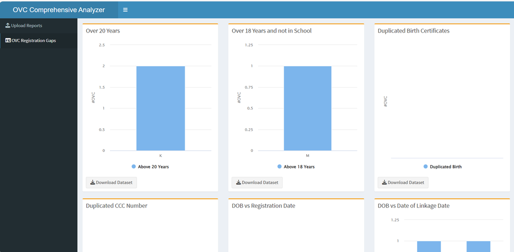

### 3. Epidemic Control Dashboard

- **Task**: Developed a tool to monitor the UNAIDS 95-95-95 agenda.
- **Action**: Visualized viral cascade data to track epidemic control efforts.
- **Result**: Improved monitoring, leading to targeted interventions and better health outcomes.

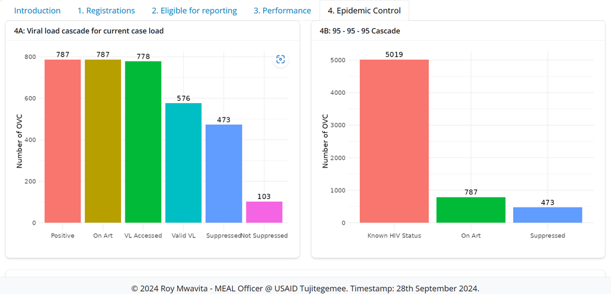

### 4. Performance Trends Dashboard

- **Task**: Designed a dashboard to analyze trends in birth certificates and case plan achievements.
- **Action**: Visualized time-series data for easy tracking and gap identification.
- **Result**: Enhanced accountability and drove program adjustments based on data insights.

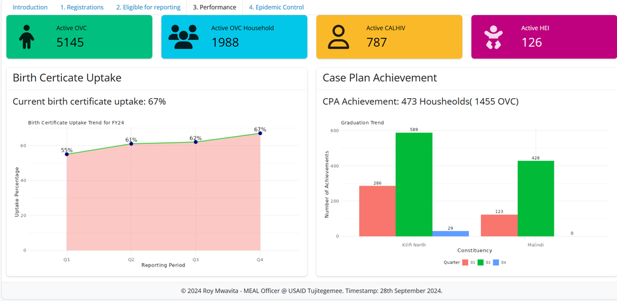